# Static choropleth map example

The example code below can be used to create a static choropleth map of England.

Install / load packages

```r
# install.packages("pacman")
pacman::p_load(
  tidyverse,
  janitor,
  data.table,
  sf,
  scales,
  RColorBrewer
)
```

Load in shapefiles for common areas in England:  
LSOA - https://geoportal.statistics.gov.uk/datasets/lower-layer-super-output-areas-december-2011-boundaries-full-clipped-bfc-ew-v3/explore?location=52.775763%2C-2.489527%2C7.39  
MSOA - https://geoportal.statistics.gov.uk/datasets/middle-layer-super-output-areas-december-2011-boundaries-full-clipped-bfc-ew-v3/explore?location=52.775763%2C-2.489527%2C7.39  
LAD - https://geoportal.statistics.gov.uk/datasets/local-authority-districts-december-2021-uk-bfc  
CCG - https://geoportal.statistics.gov.uk/datasets/clinical-commissioning-groups-april-2021-en-bfc/explore  
NHSER - https://geoportal.statistics.gov.uk/datasets/nhs-england-regions-april-2020-boundaries-en-bfc/explore

```r
shape_lsoa <- read_sf("1 - Data/shapefiles/LSOA__December_2011__Boundaries_Full_Clipped__BFC__EW_V3-shp/Lower_Layer_Super_Output_Areas__December_2011__Boundaries_Full_Clipped__BFC__EW_V3.shp") %>%
  rename(area_code = LSOA11CD)
```

[output not shown]

Read in example data. Replace with your own data with `area_code` and `measure`.

```r
measure_msoa <- fread("https://api.coronavirus.data.gov.uk/v2/data?areaType=msoa&metric=cumVaccinationFirstDoseUptakeByVaccinationDatePercentage&format=csv") %>%
  distinct() %>%
  group_by(areaCode) %>%
  filter(date == max(date)) %>%
  rename(area_code = areaCode,
         measure = cumVaccinationFirstDoseUptakeByVaccinationDatePercentage)
```

Choose shapefiles and data to use, then join together. `shape_one` is the area to be filled with colour, whilst `shape_two` will provide the boundary lines.

```r
df_measure <- measure_msoa
shape_one <- shape_msoa
shape_two <- shape_lad

# join shapefile with data
df_measure_shape <- left_join(shape_one, df_measure, by = "area_code")
```

[output not shown]

Function to automatically generate quintiles for the fill legend.

```r
scale_gen <- function(round_to = 1, small = 1, decimal_places = 0) {

  # calculate quintile cut off values, and round them to avoid interpolation
  # beyond lowest denomination in original data.
  measure_q <- quantile(df_measure_shape$measure,
                        c(0, 0.2, 0.4, 0.6, 0.8, 1),
                        na.rm = TRUE) %>%
    round_half_up(digits = decimal_places)

  # round middle quintiles to nearest round_to
  measure_q[[2]] <- round_half_up(measure_q[[2]]/round_to)*round_to
  measure_q[[3]] <- round_half_up(measure_q[[3]]/round_to)*round_to
  measure_q[[4]] <- round_half_up(measure_q[[4]]/round_to)*round_to
  measure_q[[5]] <- round_half_up(measure_q[[5]]/round_to)*round_to

  df_q <- df_measure_shape %>%
    mutate(
      fill_q = factor(
        case_when(
          measure < measure_q[[2]] ~ paste0(comma(measure_q[[1]], accuracy = round_to), " - ", comma(measure_q[[2]] - small, accuracy = round_to), sep = ""),
          measure >= measure_q[[2]] & measure < measure_q[[3]] ~ paste0(comma(measure_q[[2]], accuracy = round_to), " - ", comma(measure_q[[3]] - small, accuracy = round_to), sep = ""),
          measure >= measure_q[[3]] & measure < measure_q[[4]] ~ paste0(comma(measure_q[[3]], accuracy = round_to), " - ", comma(measure_q[[4]] - small, accuracy = round_to), sep = ""),
          measure >= measure_q[[4]] & measure < measure_q[[5]] ~ paste0(comma(measure_q[[4]], accuracy = round_to), " - ", comma(measure_q[[5]] - small, accuracy = round_to), sep = ""),
          measure >= measure_q[[5]] ~ paste0(comma(measure_q[[5]], accuracy = round_to), " - ", comma(measure_q[[6]], accuracy = round_to), sep = "")
        ),
        levels = c(
          paste0(comma(measure_q[[5]], accuracy = round_to), " - ", comma(measure_q[[6]], accuracy = round_to), sep = ""),
          paste0(comma(measure_q[[4]], accuracy = round_to), " - ", comma(measure_q[[5]] - small, accuracy = round_to), sep = ""),
          paste0(comma(measure_q[[3]], accuracy = round_to), " - ", comma(measure_q[[4]] - small, accuracy = round_to), sep = ""),
          paste0(comma(measure_q[[2]], accuracy = round_to), " - ", comma(measure_q[[3]] - small, accuracy = round_to), sep = ""),
          paste0(comma(measure_q[[1]], accuracy = round_to), " - ", comma(measure_q[[2]] - small, accuracy = round_to), sep = "")
        ),
        ordered = TRUE,
        exclude = NULL)
    )

  return(df_q)

}
```

Set quintile parameters:  
**round_to**: set denomination to round legend values to (not including min or max).  
**small**: set smallest right-most significant figure in measure (1 for count data). Used in the creation of labels to avoid overlapping quantiles.  
**decimal_places**: set decimal places to round data to in next step (0 for count data).

```r
df_q <- scale_gen(round_to = 0.1, small = 0.1, decimal_places = 1)
```

Make fill scale using the quintiles.

```r
fill_palette_q <- c(rev(brewer.pal(5, name = "Blues")), "grey80")
names(fill_palette_q) <- c(levels(df_q$fill_q))
fill_scale_q <- scale_fill_manual(values = fill_palette_q)

df_map <- df_q %>% mutate(fill_final = fill_q)
fill_scale_final <- fill_scale_q

fill_palette_q
```

[output not shown]

Plot choropleth map of England. Change text in `labs`.

```r
p_map <- df_map %>%
  filter(str_detect(area_code, "^E")) %>%
  ggplot() +
  geom_sf(aes(geometry = geometry,
              fill = fill_final),
          colour = NA) +
  geom_sf(data = subset(shape_two, str_detect(area_code, "^E")),
          aes(geometry = geometry),
          fill = NA,
          colour = "black",
          size = 0.1) +
  fill_scale_final +
  coord_sf(expand = FALSE,
           clip = "off") +
  labs(
    title = "Main chart title goes here",
    subtitle = "The subtitle could go here",
    fill = "Legend title goes here"
  ) +
  theme_void(base_size = 18,
             base_family = "sans") +
  theme(legend.position = c(0.15, 0.7),
        plot.margin = margin(0, 10, 10, 10),
        plot.title = element_text(face = "bold"),
        plot.title.position = "plot")

ggsave(p_map, dpi = 300, width = 10, height = 12, units = "in",
       filename = "3 - outputs/choropleth_2area.jpeg")
```

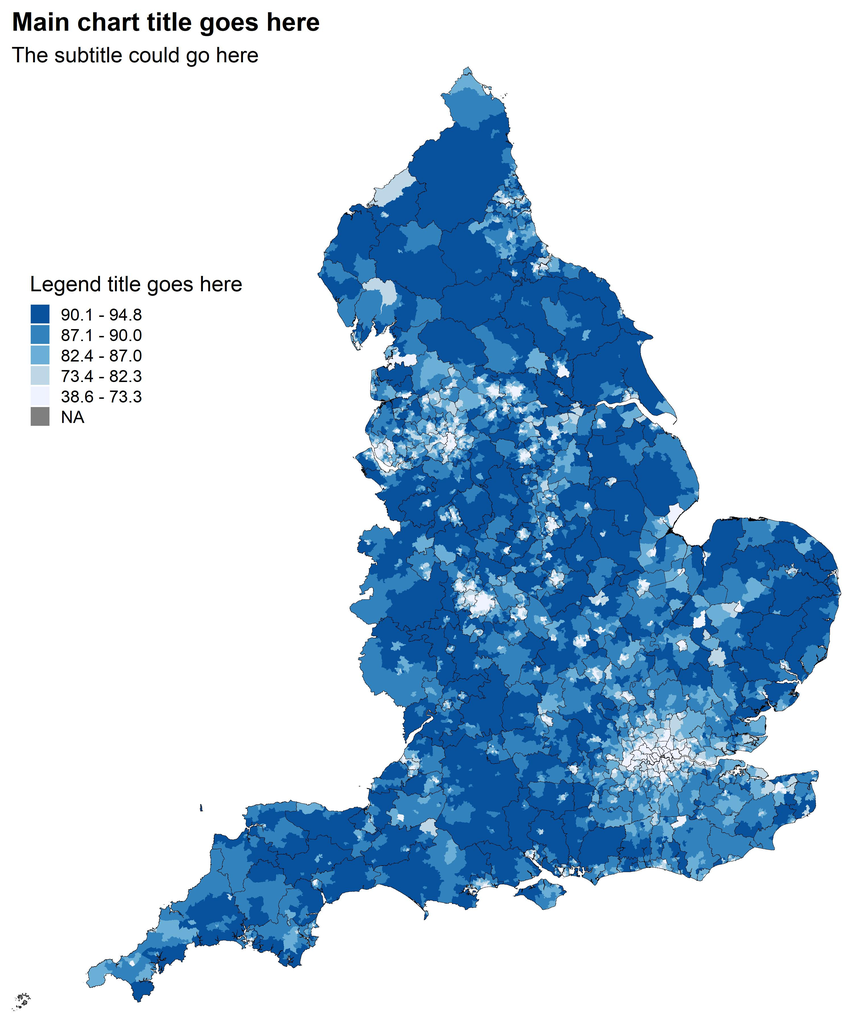